```r
library(tidyverse)
library(lubridate)
library(tsibble)
library(tsibbledata)
library(fable)
library(fabletools)
```

```r
head(nyc_bikes)
```

```
## # A tsibble: 6 x 12 [!] <America/New_York>
## # Key:       bike_id [1]
##   bike_id start_time          stop_time           start_station start_lat
##   <fct>   <dttm>              <dttm>              <fct>             <dbl>
## 1 26301   2018-02-26 19:11:03 2018-02-26 19:15:40 3186               40.7
## 2 26301   2018-02-27 07:52:49 2018-02-27 07:58:13 3203               40.7
## 3 26301   2018-02-27 12:03:27 2018-02-27 12:04:54 3202               40.7
## 4 26301   2018-02-27 13:53:51 2018-02-27 14:21:04 3638               40.7
## 5 26301   2018-02-27 14:30:42 2018-02-27 14:33:11 3638               40.7
## 6 26301   2018-02-27 16:31:04 2018-02-27 16:33:27 3187               40.7
## # … with 7 more variables: start_long <dbl>, end_station <fct>,
## #   end_lat <dbl>, end_long <dbl>, type <fct>, birth_year <dbl>,
## #   gender <fct>
```

#### I’ll be working on the nyc_bikes dataset available in the tsibbledata package. I’ll have an initial look at it to see what I’m working with. I’ll also create three new columns: one that stores only the year the bike was used, one that stores only the month the bike was used, and one that stores the date. I’ll use the data stored in start_time to create these new columns.

```r
nyc_bikes_date <- nyc_bikes %>%
  mutate(year_bike_used = year(start_time),
         month_bike_used = month(start_time),
         date_bike_used = date(start_time))
head(nyc_bikes_date)
```

```
## # A tsibble: 6 x 15 [!] <America/New_York>
## # Key:       bike_id [1]
##   bike_id start_time          stop_time           start_station start_lat
##   <fct>   <dttm>              <dttm>              <fct>             <dbl>
## 1 26301   2018-02-26 19:11:03 2018-02-26 19:15:40 3186               40.7
## 2 26301   2018-02-27 07:52:49 2018-02-27 07:58:13 3203               40.7
## 3 26301   2018-02-27 12:03:27 2018-02-27 12:04:54 3202               40.7
## 4 26301   2018-02-27 13:53:51 2018-02-27 14:21:04 3638               40.7
## 5 26301   2018-02-27 14:30:42 2018-02-27 14:33:11 3638               40.7
## 6 26301   2018-02-27 16:31:04 2018-02-27 16:33:27 3187               40.7
## # … with 10 more variables: start_long <dbl>, end_station <fct>,
## #   end_lat <dbl>, end_long <dbl>, type <fct>, birth_year <dbl>,
## #   gender <fct>, year_bike_used <dbl>, month_bike_used <dbl>,
## #   date_bike_used <date>
```

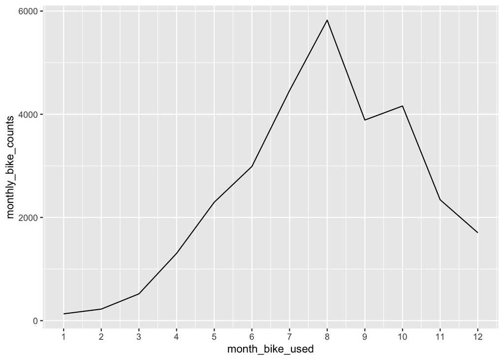

```r
nyc_bikes_date %>%
  index_by(month_bike_used) %>%
  summarise(monthly_bike_counts = sum(month_bike_used)) %>%
ggplot(aes(x = month_bike_used, y = monthly_bike_counts)) +
  scale_x_continuous(breaks = seq(12)) +
  geom_line()
```

> The problem is we only have data for 1 year, and the data appears to be seasonal, with the bikes being used more in warm months (we assume that by month number). We could use a seasonal naive model potentially but we only have 12 data points here so it would not make much sense.

#### I will now summarise the number of bike hire counts by date and make a plot of this new aggregated data.

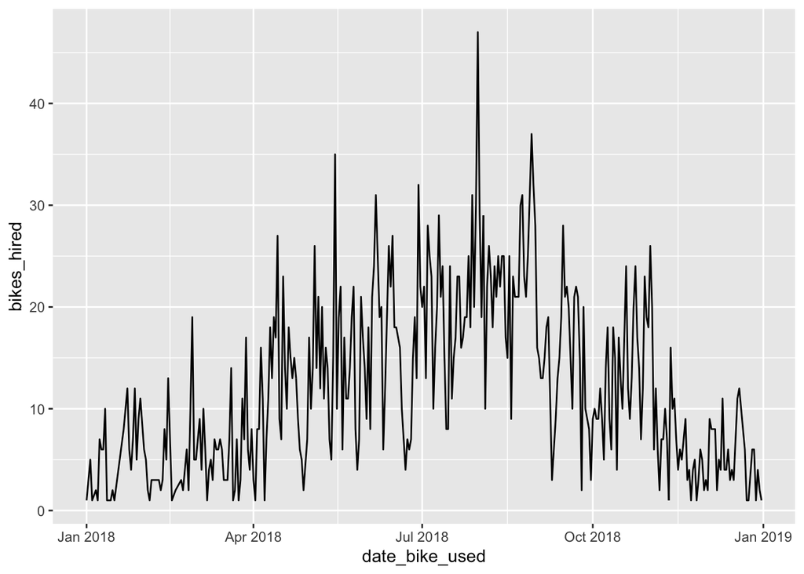

```r
nyc_bikes_date_summarised <- nyc_bikes_date %>%
  index_by(date_bike_used) %>%
  summarise(bikes_hired = n())

ggplot(nyc_bikes_date_summarised) +
  aes(x = date_bike_used, y = bikes_hired) +
  geom_line()
```

> This date aggregation data would be preferable as we have more of it. I have filtered the data to show each day of the year and we can clearly see it reflects the trend in the previous plot (by month) but we have more data to work with and thus better for creating a forecast.

#### I’ll start building a model. I will test the NAIVE, MEAN, and SNAIVE forecasting models models.

```r
# select variables I need and build model

bikes <- nyc_bikes_date_summarised %>%
  index_by(date_bike_used) %>%
  summarise(daily_bike_counts = n())

fit <- bikes %>%
  model(
    snaive = SNAIVE(daily_bike_counts),
    mean_model = MEAN(daily_bike_counts),
    naive = NAIVE(daily_bike_counts)
  )
# we get the error for data containing implicit gaps in the time series. Let's see where these are.
scan_gaps(bikes)
```

```
## # A tsibble: 18 x 1 [1D]
##    date_bike_used
##    <date>
##  1 2018-01-05
##  2 2018-01-17
##  3 2018-01-18
##  4 2018-01-19
##  5 2018-01-20
##  6 2018-01-31
##  7 2018-02-06
##  8 2018-02-07
##  9 2018-02-08
## 10 2018-02-17
## 11 2018-02-19
## 12 2018-02-20
## 13 2018-03-02
## 14 2018-03-17
## 15 2018-04-29
## 16 2018-12-20
## 17 2018-12-21
## 18 2018-12-25
```

```r
# gaps foundthroughout the series on 18 different days of the year. that is almost 3 weeks out of 52 so we can fill with the mean of the last observed value as the dates are not continuous, they are spread throughout the year.

nyc_bikes_date_fill <- nyc_bikes_date_summarised %>%
  fill_gaps(bikes_hired = as.integer(median(bikes_hired)))
head(nyc_bikes_date_fill)
```

```
## # A tsibble: 6 x 2 [1D]
##   date_bike_used bikes_hired
##   <date>               <int>
## 1 2018-01-01               1
## 2 2018-01-02               3
## 3 2018-01-03               5
## 4 2018-01-04               1
## 5 2018-01-05              10
## 6 2018-01-06               2
```

```r
filled_fit <- nyc_bikes_date_fill %>%
   model(
    snaive = SNAIVE(bikes_hired),
    mean_model = MEAN(bikes_hired),
    naive = NAIVE(bikes_hired)
  )
filled_fit
```

```
## # A mable: 1 x 3
##   snaive   mean_model naive
##   <model>  <model>    <model>
## 1 <SNAIVE> <MEAN>     <NAIVE>
```

#### I will now build a forecast based on the above fit in order to predict bike use over the next four months.

```r
forecast_4_month <- filled_fit %>%
  fabletools::forecast(h = 30*4)
forecast_4_month
```

```
## # A fable: 360 x 4 [1D]
## # Key:     .model [3]
##    .model date_bike_used bikes_hired .distribution
##    <chr>  <date>               <dbl> <dist>
##  1 snaive 2019-01-01              10 N(10,  69)
##  2 snaive 2019-01-02               6 N( 6,  69)
##  3 snaive 2019-01-03               6 N( 6,  69)
##  4 snaive 2019-01-04               1 N( 1,  69)
##  5 snaive 2019-01-05               4 N( 4,  69)
##  6 snaive 2019-01-06               2 N( 2,  69)
##  7 snaive 2019-01-07               1 N( 1,  69)
##  8 snaive 2019-01-08              10 N(10, 138)
##  9 snaive 2019-01-09               6 N( 6, 138)
## 10 snaive 2019-01-10               6 N( 6, 138)
## # … with 350 more rows
```

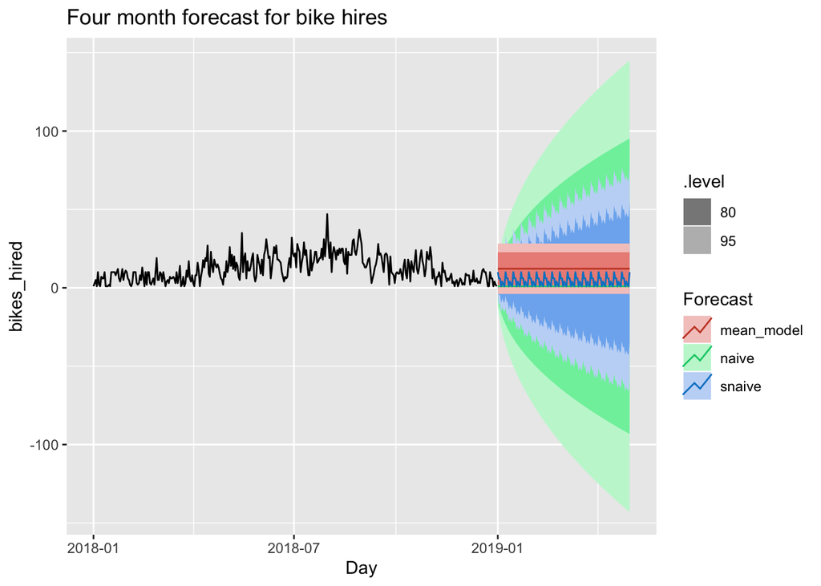

```r
forecast_4_month %>%
  autoplot(nyc_bikes_date_fill) +
  ggtitle("Four month forecast for bike hires") +
  xlab("Day") +
  guides(colour = guide_legend(title = "Forecast"))
```

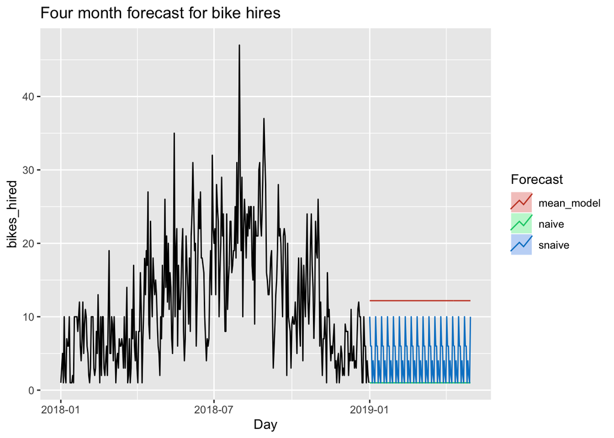

```r
# Too much clutter above so I will set level = NULL to show no predition intervals.
forecast_4_month %>%
  autoplot(nyc_bikes_date_fill, level = NULL) +
  ggtitle("Four month forecast for bike hires") +
  xlab("Day") +
  guides(colour = guide_legend(title = "Forecast"))
```